# Midterm

Author

Vicki Shen

```r
library(tidyverse)
library(ggplot2)
library(dplyr)
library(readxl)
library(stringr)
library(countrycode)
library(knitr)
```

# Introduction

Out-of-pocket (OOP) health expenditures is a metric used to represent the average amount each person spends from their own resources on health goods or services, excluding costs covered by insurance or government assistance programs. This is a crucial indicator for evaluating the level of financial security offered by a country’s healthcare system. High OOP expenses are troublesome because they might make it difficult to afford essential medical care, which could result in catastrophic health costs, especially in low- and middle-income nations. Therefore, examining patterns in OOP spending offers valuable information about the affordability, equality, and efficacy of public health financial policies.

The data used for this analysis is provided by the World Health Organization (WHO), which reported the annual out-of-pocket health expenditures (in US dollars) for all countries. The data offers a longitudinal review of changes in healthcare spending across various health systems, spanning 22 years from 2000 to 2022.

The primary research question is:

> **Which countries experienced the largest increases or decreases in out-of-pocket health expenditures per capita from 2000-2022?**

To provide deeper insights, this analysis also explores secondary trends: how OOP expenditure changes by **WHO region** and **Income Level**. This question aims to identify areas where healthcare financial protect has improved or worsened over the past two decades, by examining both absolute changes in individual countries and broader patterns across regions and income groups.

# Data Preparation

## Data Source

Data on out-of-pocket (OOP) health expenditure per capita (in US$) was acquired from the **World Health Organization (WHO) Global Health Expenditure Database (GHED)**. This publicly available database provides annual health expenditures on all WHO-member countries, including out-of-pocket (OOP) per capita, total health expenditures, and other financing indicators. The data set also includes country-level attributes such as WHO region classification and World Bank income group to help with stratified analyses.

The dataset spans from 2000-2022, capturing a period of significant global health financing changes. For this study, the primary variable of interest is OOP health expenditure per capita, expressed in US dollars.

The data was downloaded as a XLSX file directly from the WHO website: https://apps.who.int/nha/database

## Data Cleaning and Wrangling

The following steps were taken to prepare the dataset for analysis:

1. **Importing Data**: The XLXS file was imported using `read_excel()` and assigned a name `oop_raw`.

```r
oop_raw <- read_excel("~/Downloads/GHED_data.XLSX")
```

2. **Selecting Relevant Variables**: Only variables relevant to the research question were kept. To make the analysis process easier, the variables were renamed as well. These variables were assigned to a new group called `oop_official`.
- `country`
- `year`
- `oop_us`
- `region`
- `income_group`

```r
oop_official <- oop_raw |>
  rename(
    country = location,
    year = year,
    oop_us = oop_pc_usd,
    region = region,
    income_group = income
  ) |>
  select(country, year, oop_us, region, income_group)
```

```r
oop_official |>
  filter(year >= 2000 & year <= 2022)
```

4. **Cleaning and Standardizing Variables**
- Country names were standardized just in case to avoid duplicated name spelling (e.g., “United States of America” vs. “United States”).
- Income Group and Region were converted to title case and checked for miscoded entries.

```r
oop_official |>
  mutate(
    country = countrycode(country, "country.name", "country.name"),
    income_group = str_to_title(income_group),
    region = str_to_title(region)
  )
```

```r
oop_official |>
  group_by(country) |>
  filter(all(c(2000, 2022) %in% year)) |>
  ungroup()
```

6. **Creating New Variable**
- Growth Rate (%) for each country

```r
growth_rate <- oop_official |>
 filter(year %in% c(2000, 2022)) |>
  pivot_wider(names_from = year, values_from = oop_us) |>
  mutate(
    growth_pct = (`2022` - `2000`) / `2000` *100
  )
```

7. **Merge New Variable to be used in Preliminary Results**

```r
oop_final <- growth_rate |>
  left_join(
    oop_official |> select(country, region, income_group) |> distinct(),
    by = "country"
  ) |>
  mutate(
    region = coalesce(region.x, region.y),
    income_group = coalesce(income_group.x, income_group.y)
  ) |>
  select(-region.x, -region.y, -income_group.x, -income_group.y)
```

# Exploratory Analysis

## Dataset Characteristics

The clean dataset consists of out-of-pocket (OOP) health expenditure per capita (in US $) for 194 countries reported annually from 2000 to 2022, yielding a total of 4405 country-year observations. The data contains longitudinal observations spanning 23 years to allow for assessment of changes over time and comparisons across regions and income levels. Each observation represents one country-year combination with associated health expenditure and classification description.

## Variables Included

The final data set that will be used for analysis has the following key variables:

- `country`: National identifier for each WHO Member State
- `year`: Calendar year (2000-2022)
- `oop_us`: Out-of-pocket health expenditure per capita (US $). This is the primary outcome variable.
- `region`: Categorical variable indicating the WHO region classification (Africa, Americas, Eastern Mediterranean, Europe, South-East Asia, Western Pacific)
- `income_group`: Categorical variable indicating the World Bank income classification (low-income, lower-middle-income, upper-middle-income, high-income)
- `growth_pct`: Continuous variable indicating relative change in OOP between 2000 and 2022

## Distribution of Key Variables

Prior to analysis, the primary variable of interest, OOP health expenditure per capita, reveals substantial distribution across the years. The box plots in **Figure 1** reveals that the data is severely and consistently right-skewed across all years. While the majority of countries are clustered around the lower expenditures, a small number of high-income outliers show OOP numbers exceeding $2,000 USD, and the spread of these extreme outliers expanded, signaling a growing disparity in the highest levels of health spending. Despite this persistent skew, the median OOP per capita (center line of the box), shows a distinct, gradual upward trend, indicating that the typical country experienced a moderate financial contribution to healthcare over the two decades.

This upward shift is also captured by the histogram comparing the 2000 and 2022 distributions under **Figure 2**. While both years show the highest concentration of countries in the 0-100 USD range, the 2022 distribution exhibits a noticeable migration of observations into the 100-500 USD range. This confirms that the global landscape of OOP spending has shifted upward.

## Tables and Figures

```r
country_counts <- oop_official |>
  group_by(region, income_group) |>
  summarize(num_countries = n(), .groups = "drop")

kable(country_counts, caption = "Number of Countries by WHO Region and Income Group")
```

| region | income_group | num_countries |
| --- | --- | --- |
| AFR | High | 23 |
| AFR | Low | 443 |
| AFR | Lower-middle | 450 |
| AFR | Upper-middle | 138 |
| AMR | High | 255 |
| AMR | Lower-middle | 92 |
| AMR | Upper-middle | 443 |
| EMR | High | 138 |
| EMR | Low | 100 |
| EMR | Lower-middle | 184 |
| EMR | Upper-middle | 66 |
| EUR | High | 797 |
| EUR | Lower-middle | 92 |
| EUR | Upper-middle | 334 |
| SEAR | Lower-middle | 158 |
| SEAR | Upper-middle | 69 |
| WPR | High | 208 |
| WPR | Lower-middle | 254 |
| WPR | Upper-middle | 161 |

- **Figure 1**

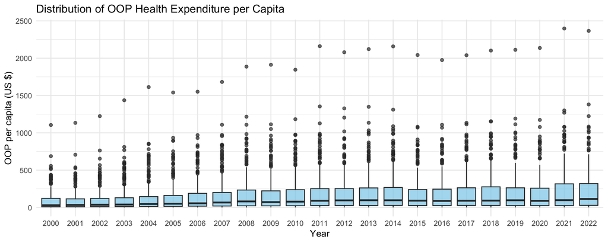

```r
# Boxplot of OOP per capita by year
ggplot(oop_official |> filter(year >= 2000 & year <= 2022),
       aes(x = factor(year), y = oop_us)) +
  geom_boxplot(fill = "skyblue", alpha = 0.7) +
  labs(title = "Distribution of OOP Health Expenditure per Capita",
       x = "Year",
       y = "OOP per capita (US $)") +
  theme_minimal()
```

- **Figure 2**

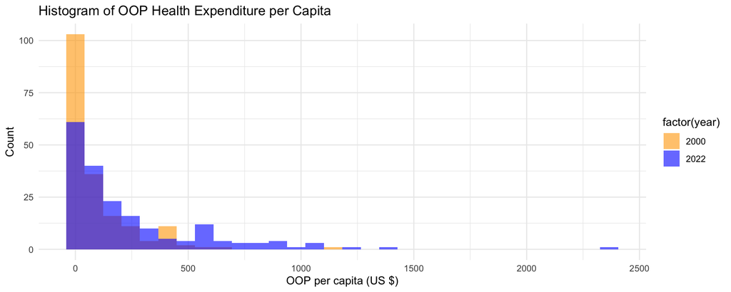

```r
# Histogram of OOP per capita for 2000 and 2022
ggplot(oop_official |> filter(year %in% c(2000, 2022)),
       aes(x = oop_us, fill = factor(year))) +
  geom_histogram(position = "identity", alpha = 0.6, bins = 30) +
  labs(title = "Histogram of OOP Health Expenditure per Capita",
       x = "OOP per capita (US $)",
       y = "Count") +
  scale_fill_manual(values = c("2000" = "orange", "2022" = "blue")) +
  theme_minimal()
```

- **Figure 3**

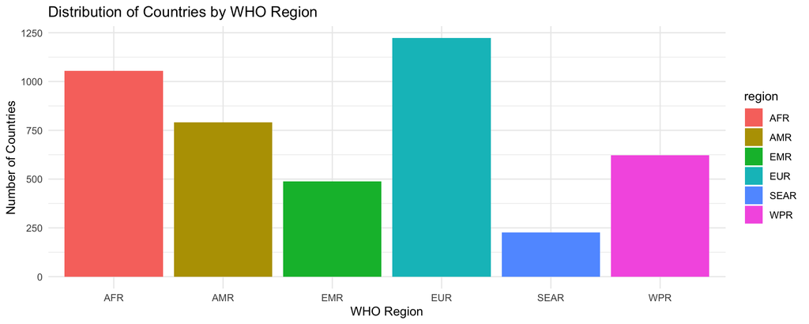

```r
# Bar Chart of Distribution of WHO Regions
ggplot(oop_official, aes(x = region, fill = region)) +
  geom_bar() +
  labs(title = "Distribution of Countries by WHO Region",
       x = "WHO Region",
       y = "Number of Countries") +
  theme_minimal()
```

- **Figure 4**

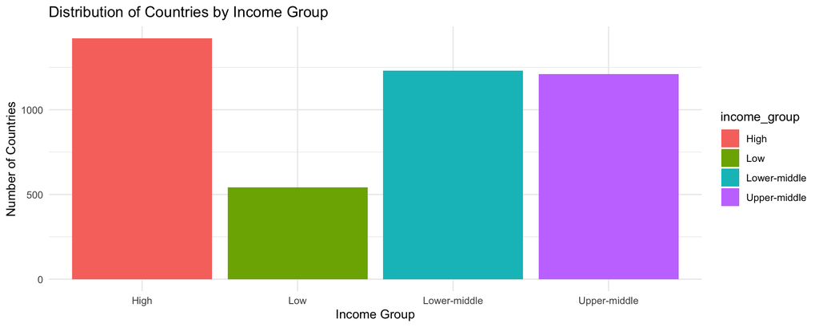

```r
# Bar Chart of Distribution of Income Groups
ggplot(oop_official, aes(x = income_group, fill = income_group)) +
  geom_bar() +
  labs(title = "Distribution of Countries by Income Group",
       x = "Income Group",
       y = "Number of Countries"
  ) +
  theme_minimal()
```

Overall, the exploratory analysis confirms that this dataset is suitable for addressing the primary research question while also allowing for secondary analyses by WHO region and income group.

# Preliminary Results

## Overview of Out-of-Pocket Health Expenditures (2000-2022)

This section presents the results of the primary research question. In addition, follow-up analyses explore trends across WHO regions and income levels, highlighting patterns in OOP spending growth and disparities between income groups.

## Countries with the Largest Increases and Decreases

A histogram of growth rates reveal a **right-skewed distribution**, indicating that while most countries experienced moderate increases, a smaller subset had exceptionally high growth. However, the magnitude of change varied widely. Some countries showed major growth, while others experienced declines.

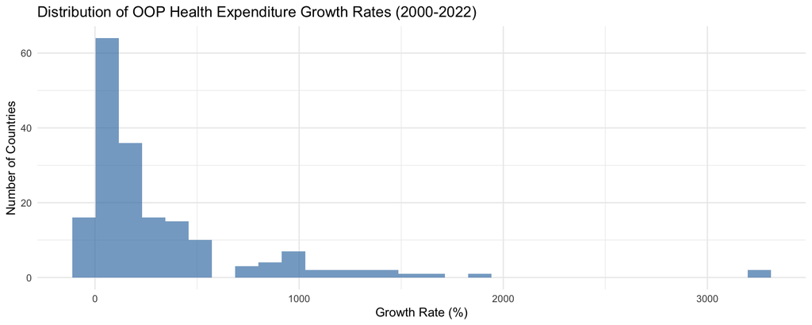

```r
ggplot(oop_final, aes(x = growth_pct)) +
  geom_histogram(bins = 30, fill = "steelblue", alpha = 0.7) +
  labs(title = "Distribution of OOP Health Expenditure Growth Rates (2000-2022)",
       x = "Growth Rate (%)",
       y = "Number of Countries") +
  theme_minimal()
```

The two tables below displays the top five countries with the largest increase and the top five countries with the largest decreases in OOP health expenditure per capita.

```r
# Identify top 5 increases and decreases
top_increase <- oop_final |>
  filter(!is.na(growth_pct)) |>
  arrange(desc(growth_pct)) |>
  slice_head(n = 5) |>
  select(country, region, income_group, growth_pct)

top_decrease <- oop_final |>
  filter(!is.na(growth_pct)) |>
  arrange(growth_pct) |>
  slice_head(n = 5) |>
  select(country, region, income_group, growth_pct)
```

```r
kable(top_increase, caption = "Top 5 Countries with Largest Increase in OOP Health Expenditure per Capita (2000-2022)")
```

Top 5 Countries with Largest Increase in OOP Health Expenditure per Capita (2000-2022)

| country | region | income_group | growth_pct |
| --- | --- | --- | --- |
| Armenia | EUR | Upper-middle | 3253.950 |
| Mongolia | WPR | Lower-middle | 3251.827 |
| Serbia | EUR | Upper-middle | 1872.084 |
| Kiribati | WPR | Lower-middle | 1635.666 |
| Belarus | EUR | Upper-middle | 1499.853 |

```r
kable(top_decrease, caption = "Top 5 Countries with Largest Decrease in OOP Health Expenditure per Capita (2000-2022)")
```

Top 5 Countries with Largest Decrease in OOP Health Expenditure per Capita (2000-2022)

| country | region | income_group | growth_pct |
| --- | --- | --- | --- |
| Syrian Arab Republic | EMR | Low | -54.31695 |
| Lebanon | EMR | Lower-middle | -46.69251 |
| Gambia | AFR | Low | -43.84804 |
| Brunei Darussalam | WPR | High | -37.94174 |
| Libya | EMR | Upper-middle | -33.08191 |

## Trends by WHO Region

```r
region_trends <- oop_official |>
  group_by(region, year) |>
  summarize(mean_oop = mean(oop_us, na.rm = TRUE), .groups = "drop")

kable(region_trends |>
        filter(year %in% c(2000, 2022)) |>
        pivot_wider(names_from = year, values_from = mean_oop),
      caption = "Average OOP Health Expenditures per Capita by WHO Region (2000 vs. 2022)")
```

Average OOP Health Expenditures per Capita by WHO Region (2000 vs. 2022)

| region | 2000 | 2022 |
| --- | --- | --- |
| AFR | 14.28538 | 36.19754 |
| AMR | 119.46210 | 291.27057 |
| EMR | 73.64778 | 100.64207 |
| EUR | 190.65015 | 505.37495 |
| SEAR | 23.79342 | 56.73543 |
| WPR | 71.06678 | 199.33421 |

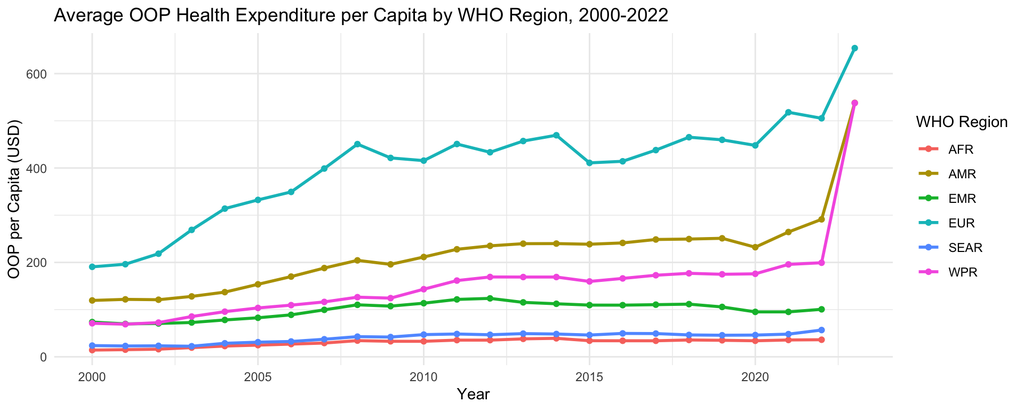

```r
ggplot(region_trends, aes(x = year, y = mean_oop, colour = region)) +
  geom_line(size = 1) +
  geom_point() +
  labs(title = "Average OOP Health Expenditure per Capita by WHO Region, 2000-2022",
       x = "Year",
       y = "OOP per Capita (USD)",
       color = "WHO Region") +
  theme_minimal()
```

## Average OOP per Capita by Income Level

```r
income_trends <- oop_official |>
  group_by(income_group, year) |>
  summarize(mean_oop = mean(oop_us, na.rm = TRUE), .groups = "drop")

kable(income_trends |>
        filter(year %in% c(2000, 2022)) |>
        pivot_wider(names_from = year, values_from = mean_oop),
      caption = "Average OOP Health Expenditure per Capita by Income Level (2000 vs 2022)")
```

Average OOP Health Expenditure per Capita by Income Level (2000 vs 2022)

| income_group | 2000 | 2022 |
| --- | --- | --- |
| High | 234.120187 | 556.43816 |
| Low | 7.815203 | 19.16256 |
| Lower-middle | 19.380361 | 48.22167 |
| Upper-middle | 52.736632 | 171.13103 |

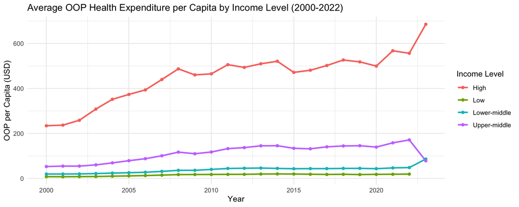

```r
ggplot(income_trends, aes(x = year, y = mean_oop, colour = income_group)) +
  geom_line(size = 1) +
  geom_point() +
  labs(title = "Average OOP Health Expenditure per Capita by Income Level (2000-2022)",
       x = "Year",
       y = "OOP per Capita (USD)",
       color = "Income Level") +
  theme_minimal()
```

*Interpretation*: The average OOP per capita variable was used again to further explore disparities. Results show a clear income trend: high-income countries consistently exhibit higher OOP spending per capita compared to lower-middle and low-income countries.

# Brief Conclusion

This data analysis examined changes in out-of-pocket (OOP) health expenditures per capita across WHO Member States from 2000 to 2022. To attempt to respond to the primary research question, the Syrian Arab Republic saw the biggest decrease in OOP spending, while Armenia saw the most increase. This difference in healthcare spending demonstrates how diverse global trends in healthcare funding are.

Secondary analyses demonstrated distinct patterns by WHO region and income level. Per capita OOP expenditures tend to be greater in the Americas and Europe, but stayed low in South-East Asia and African countries. High-income nations consistently led OOP spending when income groups were divided, whereas low-income nations remained largely unchanged. Over time, the upper-middle-income countries also gradually increased their OOP spending.

The findings show that, despite a general increase in OOP spending over the past two decades, regional and income-level differences still exist. These results emphasize how crucial it is to keep an eye on healthcare financial protection and implement focused policy changes to lessen the burden of out-of-pocket expenses, especially in areas where spending is rising quickly.